# Practical ML Project

Grace

12/9/2016

```r
library(dplyr)
```

```r
library(ggplot2)
library(rpart)
library(rpart.plot)
suppressMessages(library(randomForest))
library(caret)
library(gbm)
```

# Introduction to the Project

### Background

Using devices such as Jawbone Up, Nike FuelBand, and Fitbit it is now possible to collect a large amount of data about personal activity relatively inexpensively. These type of devices are part of the quantified self movement – a group of enthusiasts who take measurements about themselves regularly to improve their health, to find patterns in their behavior, or because they are tech geeks. One thing that people regularly do is quantify how much of a particular activity they do, but they rarely quantify how well they do it. In this project, your goal will be to use data from accelerometers on the belt, forearm, arm, and dumbell of 6 participants. They were asked to perform barbell lifts correctly and incorrectly in 5 different ways. More information is available from the website here: http://groupware.les.inf.puc-rio.br/har (see the section on the Weight Lifting Exercise Dataset).

### Data

The training data for this project are available here: https://d396qusza40orc.cloudfront.net/predmachlearn/pml-training.csv The test data are available here: https://d396qusza40orc.cloudfront.net/predmachlearn/pml-testing.csv

### Goal

The goal of your project is to predict the manner in which they did the exercise. This is the “classe” variable in the training set. You may use any of the other variables to predict with. You should create a report describing how you built your model, how you used cross validation, what you think the expected out of sample error is, and why you made the choices you did. You will also use your prediction model to predict 20 different test cases.

# Loading data

```r
setwd("/Users/Grace/Desktop/Data Science/Practical ML")
training <- read.csv("pml-training.csv",na.strings=c("NA","","#DIV/0!"))
testing <- read.csv("pml-testing.csv",na.strings=c("NA","","#DIV/0!"))
```

Split data into training and testing set

```r
set.seed(123)
inTrain <- createDataPartition(training$class,p=.67,list=FALSE)
train <- training[inTrain,]
test <- training[-inTrain,]
dim(train);dim(test)
```

```
## [1] 13148   160
```

```
## [1] 6474  160
```

Get a sense of the dataset

```r
dim(train)
```

```
## [1] 13148   160
```

```r
vars <- names(train) %in% c("classe","new_window","user_name")
sapply(train[vars],summary)
```

```
## $user_name
##   adelmo carlitos  charles   eurico   jeremy    pedro
##     2621     2065     2350     2106     2296     1710
##
## $new_window
##    no   yes
## 12865   283
##
## $classe
##    A    B    C    D    E
## 3739 2544 2293 2155 2417
```

# Data Cleaninig

Remove Near Zero Variance vars nearZeroVar diagnoses predictors that have 1) one unique value 2)few unique values relative to the number of sample 3) ratio of the frequency of the most common value to the second common value is large Since there are 160 predictors in the sample, it is very necessary to remove variables with poor quality.

```r
train <- train[,-1] #remove the first column X
nzvars <- nearZeroVar(train,saveMetric=TRUE)
train <- train[,nzvars$nzv==FALSE]
dim(train)
```

```
## [1] 13148   126
```

Remove columns with over 60% NAs

```r
M <- sapply(train, function(x) sum(is.na(x))/length(x))
trainc <-train[names(train)[M<0.6]]
var <- names(train)[M<0.6]

testc<- test[var] # select the same variables
testing <- testing[var[-58]] #select the same variable except classe
dim(trainc)
```

```
## [1] 13148    58
```

```r
dim(testc)
```

```
## [1] 6474   58
```

```r
dim(testing)
```

```
## [1] 20 57
```

# Model Fitting

## Decision Trees

It is a typical classification problem; therefore, I will start with an easy method, decision trees, to extract important features

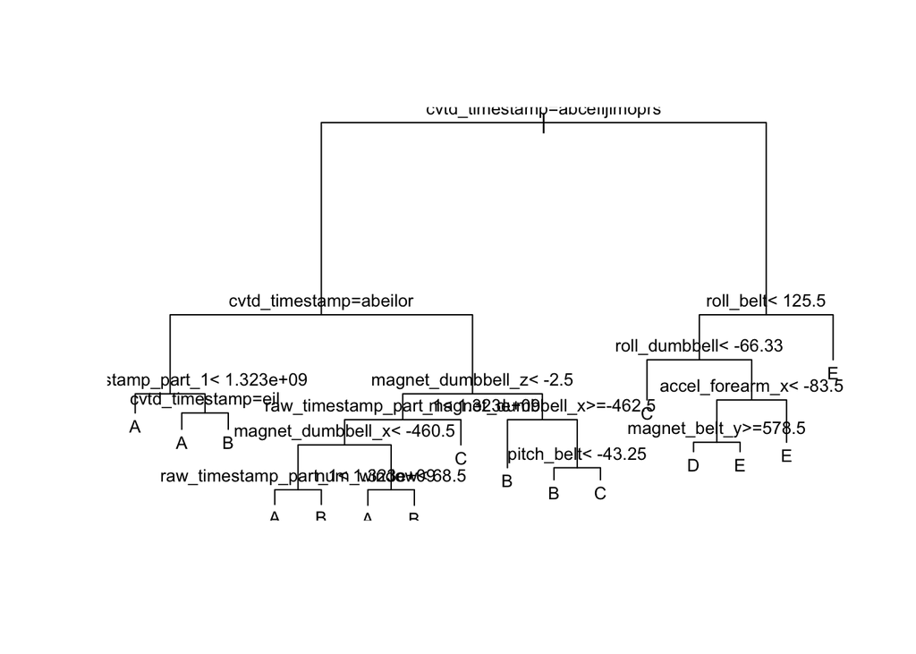

```r
set.seed(123)
mod.tree <- rpart(classe~.,data=trainc,method="class")
plot(mod.tree)
text(mod.tree, cex=0.8)
```

```r
#text(mod.tree, use.n=TRUE, cex=0.8)
predict.tree<-predict(mod.tree,testc,type="class")
M.tree <- confusionMatrix(predict.tree,testc$classe)
M.tree
```

```
## Confusion Matrix and Statistics
##
##           Reference
## Prediction    A    B    C    D    E
##          A 1757   50    6    1    0
##          B   64 1030   57   48    0
##          C   20  165 1043  170   46
##          D    0    8   12  661   62
##          E    0    0   11  181 1082
##
## Overall Statistics
##
##                Accuracy : 0.8608
##                  95% CI : (0.8522, 0.8692)
##     No Information Rate : 0.2844
##     P-Value [Acc > NIR] : < 2.2e-16
##
##                   Kappa : 0.824
##  Mcnemar's Test P-Value : NA
##
## Statistics by Class:
##
##                      Class: A Class: B Class: C Class: D Class: E
## Sensitivity            0.9544   0.8220   0.9238   0.6230   0.9092
## Specificity            0.9877   0.9676   0.9250   0.9849   0.9637
## Pos Pred Value         0.9686   0.8590   0.7223   0.8896   0.8493
## Neg Pred Value         0.9820   0.9577   0.9829   0.9302   0.9792
## Prevalence             0.2844   0.1935   0.1744   0.1639   0.1838
## Detection Rate         0.2714   0.1591   0.1611   0.1021   0.1671
## Detection Prevalence   0.2802   0.1852   0.2230   0.1148   0.1968
## Balanced Accuracy      0.9710   0.8948   0.9244   0.8039   0.9365
```

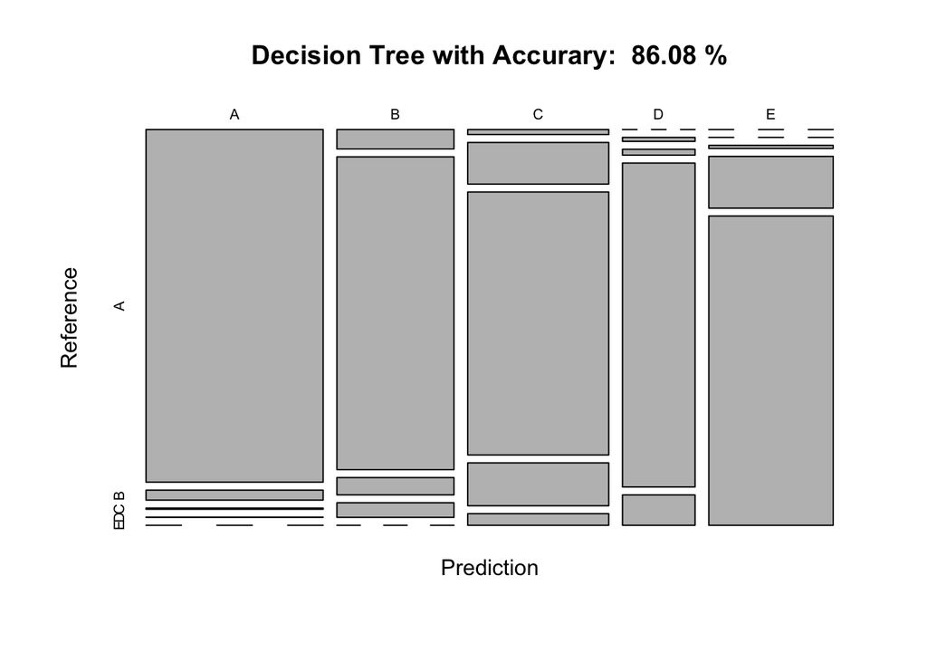

```r
accuracy<-M.tree$overall[1]
plot(M.tree$table,main=paste("Decision Tree with Accurary: ", round(accuracy,4)*100, "%"))
```

## Random Forests RF prevents overfitting by coercing to consider a subset of variables n each split

```r
set.seed(123)
sqrt(ncol(trainc)-1)
```

```
## [1] 7.549834
```

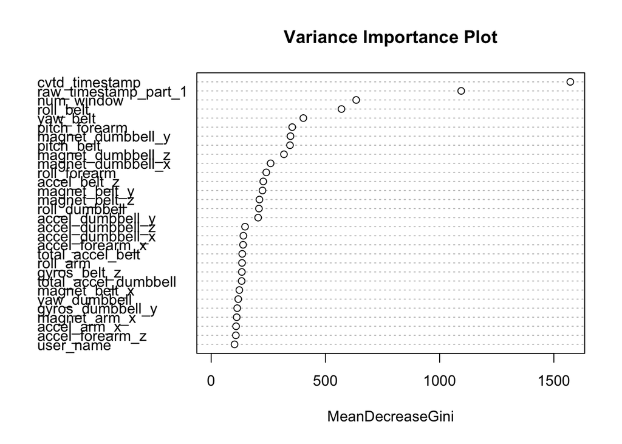

```r
mod.rf <- randomForest(classe~., data=trainc, mtry=7,
                       keep.forest=TRUE)
# Usually m, number of variables considered at each split, is the square root of the total number of variables
varImpPlot(mod.rf,type=2,main="Variance Importance Plot")
```

```r
predict.rf <- predict(mod.rf,testc,type="class")
M.rf <- confusionMatrix(predict.rf,testc$classe)
M.rf
```

```
## Confusion Matrix and Statistics
##
##           Reference
## Prediction    A    B    C    D    E
##          A 1840    1    0    0    0
##          B    1 1252    4    0    0
##          C    0    0 1125    3    0
##          D    0    0    0 1055    0
##          E    0    0    0    3 1190
##
## Overall Statistics
##
##                Accuracy : 0.9981
##                  95% CI : (0.9968, 0.999)
##     No Information Rate : 0.2844
##     P-Value [Acc > NIR] : < 2.2e-16
##
##                   Kappa : 0.9977
##  Mcnemar's Test P-Value : NA
##
## Statistics by Class:
##
##                      Class: A Class: B Class: C Class: D Class: E
## Sensitivity            0.9995   0.9992   0.9965   0.9943   1.0000
## Specificity            0.9998   0.9990   0.9994   1.0000   0.9994
## Pos Pred Value         0.9995   0.9960   0.9973   1.0000   0.9975
## Neg Pred Value         0.9998   0.9998   0.9993   0.9989   1.0000
## Prevalence             0.2844   0.1935   0.1744   0.1639   0.1838
## Detection Rate         0.2842   0.1934   0.1738   0.1630   0.1838
## Detection Prevalence   0.2844   0.1942   0.1742   0.1630   0.1843
## Balanced Accuracy      0.9996   0.9991   0.9979   0.9972   0.9997
```

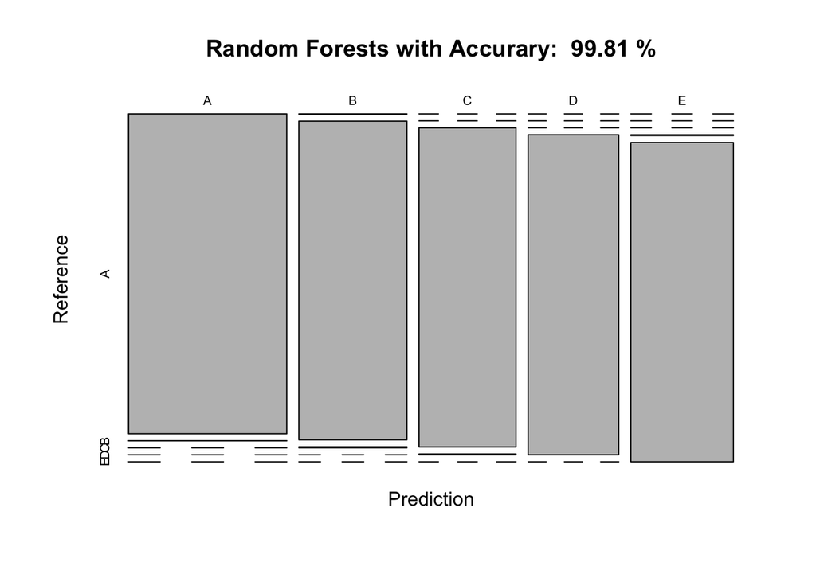

```r
accuracy<-M.rf$overall[1]
plot(M.rf$table,main=paste("Random Forests with Accurary: ", round(accuracy,4)*100, "%"))
```